# Hotel Report +

Hotelics

2021-05-17

# Einführung

Lieber Ivo,

dieses Dokument beinhaltet die Resultate unseres Capstone Projektes. Im ersten Teil wird die Erstellung der Klassifikatoren beschrieben, während der zweite Teil ein beispielhafter Hotelbericht beinhaltet,der Hotelics seinen Kunden anbietet.

# Modelle kreieren

## Sentiment Modell

Im ersten Schritt wird die Datei eingelesen und ein Überblick über die Daten verschafft.

```r
library(data.table)
reviews = fread("Hotel_Reviews.csv")
```

Wir versuchen nun das Land der Hotels herauszufinden. Dies tun wir anhand des Längen- und Breitengrades. Dafür müssen wir aber noch die NA’s bei diesen Werten entfernen.

```r
library(maps)

# Da gewisse Längen- oder Breitengrade NAs enthalten, müssen diese entfernt werden. Da es sich um sehr wenige vom Datensatz handelt, spielt dies keine Rolle.
reviews = reviews[!is.na(reviews$lat) | !is.na(reviews$lng),]

# Library erkennt das Land anhand der Längen- und Breitengrade.
reviews$Country = map.where(database="world", reviews$lng, reviews$lat)

# zur Bearbeitung des Datensatz werden nur Einträge zu Hotels aus Österreich genommen
reviews = reviews[reviews$Country == "Austria",]
```

Um die Kommentare zu verarbeiten und zu analysieren, werden sie hier proprocessed.

```r
library(SentimentAnalysis)
# Sentiment der negativen und positiven Reviews werden berechnet und zu jedem Kommentar gespeichert.
reviews$Negative_Review_Sentiment = analyzeSentiment(reviews$Negative_Review)$SentimentQDAP
reviews$Positive_Review_Sentiment = analyzeSentiment(reviews$Positive_Review)$SentimentQDAP

# Nun soll die Performance überprüft werden. Da hier keine klassische Klassifikation vorliegt,
# wird eine eigene Confusiomatrix erstellt.
# Sentimen QDAP > 0 bedeutet positiv.
table_neg = table(reviews$Negative_Review_Sentiment <= 0) # Wie viele wurden richtig klassifiziert und wie viele nicht.
table_pos = table(reviews$Positive_Review_Sentiment >= 0) # Wie viele wurden richtig klassifiziert und wie viele nicht.

tp = table_pos["TRUE"]
tn = table_neg["TRUE"]
fp = table_pos["FALSE"]
fn = table_neg["FALSE"]

# anhand der eigens erstellten Confusion Matrix können die Accuracy, Recall und Precision berechnet werden.
accuracy  = (tp + tn) / (tp + tn + fn + fp)
recall    = (tp) / (tp + fn)
precision = (tp) / (tp + fp)
```

Bei der Berechnung der Confusion Matrix dieses “Modells” werden keine Trainings- und Testdaten unterschieden, da wir lediglich eine Library verwenden, die einen Dictionary für die Sentiment-Analyse nutzt. Darum gibt es keinen Overfit auf die “Trainingsdaten”.

Die Bewertungsmassstäbe des Klassifikators sind die folgenden:

- Accuracy: 0.8533819
- Recall: 0.7772318
- Precision: 0.9921249

Nach der Analyse der Sentiments kann festgehalten werden, dann das Sentiment-Modell mit der Library SentimentAnalysis und dem QDAP-Sentiment ziemlich gut funktioniert. Mit einer solchen Accuracy kann sehr gut weitergearbeitet werden.

## Topic Model

Bevor wir das Topic Model trainieren, werden die Daten noch gesplittet. Dies, weil es dadurch einfacher wird, das Modell korrekt zu erlernen mit allen möglichen Datensätzen. Dieser Schritt wurde im Nachhinein und nach häufigem Ausprobieren erstellt. Es wird das Reviews DataFrame gesplittet. Negative und positive Kommentare werden getrennt. Der Grund dafür ist, dass wir so einzelne unnötige Kommentare wie “No Negative” rausnehmen können. Diese tragen keinen Inhalt bei und verändern die Topics.

```r
####################################
# splitNegativeAnsPositiveReviews
#
# Diese Funktion wird gebraucht, um die Datenstruktur (pro Zeile jeweils einen positiven und negativen Review) für die Verwendung fürs Topic Modelling zu verbessern.
# Positive und negative Reviews werden in einzelne DataFrames aufgeteilt. So erhält man eine einheitliche Struktur des DataFrames. Das vereinfacht das spätere Handling enorm.
# Diese Funktion kann später wiederverwendet werden.
#
####################################
splitNegativeAndPositiveReviews = function(splittable_reviews){
  negatives = splittable_reviews
  positives = splittable_reviews

  # im negativen Review-DataFrame löschen wir die positiven Kommentare und deren Sentiment heraus
  negatives$Positive_Review = NULL
  negatives$Review_Total_Positive_Word_Counts = NULL
  negatives$Positive_Review_Sentiment = NULL
  colnames(negatives)[colnames(negatives) == "Negative_Review"] = "Review"
  colnames(negatives)[colnames(negatives) == "Review_Total_Negative_Word_Counts"] = "Review_Total_Word_Counts"
  colnames(negatives)[colnames(negatives) == "Negative_Review_Sentiment"] = "Review_Sentiment"

  # im negativen Review-DataFrame löschen wir die positiven Kommentare und deren Sentiment heraus
  positives$Negative_Review = NULL
  positives$Review_Total_Negative_Word_Counts = NULL
  positives$Negative_Review_Sentiment = NULL
  colnames(positives)[colnames(positives) == "Positive_Review"] = "Review"
  colnames(positives)[colnames(positives) == "Review_Total_Positive_Word_Counts"] = "Review_Total_Word_Counts"
  colnames(positives)[colnames(positives) == "Positive_Review_Sentiment"] = "Review_Sentiment"

  return(list(negatives = negatives, positives = positives))

}

# Die Reviews werden gesplittet und in einzelne DataFrames gespeichert
splittedData = splitNegativeAndPositiveReviews(reviews)
reviews.negative = splittedData$negatives
reviews.positive = splittedData$positives
```

Die gesplitteten Daten werden nun bereinigt. Beispielsweise gibt es leere Kommentare oder solche, mit “No Negative” / “No Positive” als Inhalt. Da dies im Topic Modelling nichts nützt, werden diese entfernt.

```r
####################################
# removeNoiseData
#
# Diese Funktion wird gebraucht, um verzerrende Daten im Datensatz zu entfernen. Beispielsweise enthalten die Daten sehr häufig "no negative". Um zu verhindern, dass dies dann im Topic vorkommt, wird das entfernt. Obwohl es sehr viele solche Reviews im Datensatz hat, lohnt es sich die Daten zu entfernen, weil sie keinen inhaltlichen Mehrwert liefern.
# Diese Funktion kann später wiederverwendet werden.
#
####################################
removeNoiseData = function(reviews.data){
  reviews.prepared = reviews.data

  # NAs bei den Kommentaren werden entfernt.
  reviews.prepared = reviews.prepared[!is.na(reviews.prepared$Review)]
  # leere Kommentare werden entfernt
  reviews.prepared = reviews.prepared[!(reviews.prepared$Review == "")]
  # "no negative" Kommentare werden entfernt (sind extrem viele im Datensatz und verzerren das Modell)
  reviews.prepared = reviews.prepared[!(tolower(reviews.prepared$Review) == "no negative")]
  # "no positive" Kommentare werden entfernt (sind extrem viele im Datensatz und verzerren das Modell)
  reviews.prepared = reviews.prepared[!(tolower(reviews.prepared$Review) == "no positive")]
  # "nothing" Kommentare werden entfernt
  reviews.prepared = reviews.prepared[!(tolower(reviews.prepared$Review) == "nothing")]

  return (reviews.prepared)
}

# die Noise Daten werden aus den Reviews entfernt
reviews.negative = removeNoiseData(reviews.negative)
reviews.positive = removeNoiseData(reviews.positive)
```

Nun soll ein Topic Model trainiert werden. Dieses soll in den Daten verschiedene Topics erkennen.

```r
# load libraries
library(tm)
library(topicmodels)
library(reshape2)
library(pals)

####################################
# preprocessData
#
# Mit dieser Funktion können auf wiederverwendbare Art und Weise die Daten vorverarbeitet werden. Das bedeutet, dass Zahlen, Sonderzeichen und Stoppwörter entfernt werden. Zudem werden die einzelnen Wörter gestemmt und in eine DocumentTermMatrix geladen.
# Die DocumenttermMatrix ist für das Topic-Modelling notwendig.
#
####################################
preprocessData = function(data_to_preproceed){
  # Alles was keine Buchstaben sind, wird entfernt
  data_to_preproceed = gsub("[^A-Za-z]", " ", data_to_preproceed)

  # Corpus für die Reviews erstellen
  data_to_preproceed = VectorSource(data_to_preproceed)
  corpus.data = Corpus(data_to_preproceed)

  # Nun werden die Daten Preprocessed
  corpus.data = tm_map(corpus.data, content_transformer(tolower)) # Hier wird alles zu lower_case umgewandelt.
  corpus.data = tm_map(corpus.data, removeWords, stopwords("english")) # Englische Stopwörter entfernen
  corpus.data = tm_map(corpus.data, stemDocument, language="english") # Stemming der Wörter
  corpus.data = tm_map(corpus.data, stripWhitespace) # Nur noch einzelnen Leerzeichen

  # Kreieren einer Term Document Matrix
  dtm.preprocessed = DocumentTermMatrix(corpus.data, control=list(weighting = weightTf))
  dtm.preprocessed = removeSparseTerms(dtm.preprocessed, 0.9999) # Alle Worte, die in mehr als 99.99% der Dokumente nicht vorkommen entfernt werden. Dieser Wert wurde aufgrund der Anzahl vorhandener Sparse-Einträge so ausgesucht.

  return (dtm.preprocessed)

}
```

```r
# Nun werden die positiven und negativen Reviews aneinandergehängt, um sie gemeinsam fürs Topic Modelling zu verwenden.
all_reviews = append(reviews.negative$Review, reviews.positive$Review)

# Alle Daten werden preprocessed
dtm = preprocessData(all_reviews)

# Leere Zeilen in der DTM sollen entfernt werden
sel_idx = slam::row_sums(dtm) > 0 # Nur Zeilen auswählen, die Inhalt enthalten
dtm = dtm[sel_idx, ] # Nur die auswählen, die auch Inhalt enthalten

# Nun muss die Anzahl an Topics bestimmt werden. Hier müssen wir eine Annahme tätigen. Mehrere Versuche haben ergeben, dass 20 eine sinnvolle Zahl ist. Auch aus fachlicher Sicht, machen 20 Topics durchaus Sinn. Dadurch erfasst man viele Themen, allerdings sind sie noch analysierbar.
anzahl_topics = 20
# Aus 4 Wörtern soll der Topic-Name erzeugt werden.
anzahl_woerter = 4

# Nun berechnen wir das LDA Modell
set.seed(123)
topicModel = LDA(dtm, anzahl_topics, method="Gibbs", control=list(iter = 500, verbose = 25))
```

```
## K = 20; V = 3534; M = 57863
## Sampling 500 iterations!
## Iteration 25 ...
## Iteration 50 ...
## Iteration 75 ...
## Iteration 100 ...
## Iteration 125 ...
## Iteration 150 ...
## Iteration 175 ...
## Iteration 200 ...
## Iteration 225 ...
## Iteration 250 ...
## Iteration 275 ...
## Iteration 300 ...
## Iteration 325 ...
## Iteration 350 ...
## Iteration 375 ...
## Iteration 400 ...
## Iteration 425 ...
## Iteration 450 ...
## Iteration 475 ...
## Iteration 500 ...
## Gibbs sampling completed!
```

```r
topTermsPerTopic = terms(topicModel, anzahl_woerter)
# Topic-Namen erzeugen
topicNames = apply(topTermsPerTopic, 2, paste, collapse=" ")
```

An dieser Stelle werden nun anhand unseres Topic Modells die Themen der negativen Kommentare eruiert. Das wahrscheinlichste Thema wird in das Review DataFrame gespeichert.

```r
##################################################
# Topics für die negativen Kommentare herausfinden
# An dieser Stelle werden nun für alle negativen Reviews die einzelnen Topics bestimmt.
##################################################
dtm.new_data = preprocessData(reviews.negative$Review)

# Leere Zeilen in der DTM sollen entfernt werden
sel_idx = slam::row_sums(dtm.new_data) > 0 # Nur Zeilen auswählen, die Inhalt enthalten
dtm.new_data = dtm.new_data[sel_idx, ] # Nur die auswählen, die auch Inhalt enthalten

# Die Reviews ohne zuordenbare Kommentar-Inhalte müssen rausgelöscht werden, damit später die Topics der Kommentare den Reviews zugewiesen werden können.
reviews.negative = reviews.negative[sel_idx,]

# Topics bestimmen
predicted_topics = posterior(topicModel, dtm.new_data)

####################################
# getTopTopics
#
# Anhand der bestimmten Topics der einzelnen Kommentare wird mit dieser Funktion das wahrscheinlichste Topic ermittelt. Diese gilt als Topic eines Kommentars.
#
####################################
getTopTopics = function(topics_probabilities, topics){
  # hier holen wir uns die Indexes der Hauptthemen der Kommentare
  max.ind = apply(topics_probabilities,1,which.max)
  return(topics[max.ind])
}

# Das Topic pro Kommentar ermitteln.
toptopics = getTopTopics(predicted_topics$topics, topics = topicNames)

reviews.negative$Topic = toptopics
```

Anschliessend werden anhand unseres Topic Modells die Themen der positiven Kommentare eruiert. Das wahrscheinlichste Thema wird in das Review DataFrame gespeichert. Eigentlich könnte man diese Kategorisierung auch in einem Schritt mit den negativen und positiven Kommentaren zusammen machen. Für die bessere Verständlichkeit für den Code, wurde dies aber getrennt gemacht. Für neue Hotels würde dies gleichzeitig gemacht werden (siehe unten).

```r
##################################################
# Topics für die positiven Kommentare herausfinden
# An dieser Stelle werden nun für alle positiven Reviews die einzelnen Topics bestimmt.
##################################################
dtm.new_data = preprocessData(reviews.positive$Review)

# Leere Zeilen in der DTM sollen entfernt werden
sel_idx = slam::row_sums(dtm.new_data) > 0 # Nur Zeilen auswählen, die Inhalt enthalten
dtm.new_data = dtm.new_data[sel_idx, ] # Nur die auswählen, die auch Inhalt enthalten

# Die Reviews ohne zuordenbare Kommentar-Inhalte müssen rausgelöscht werden, damit später die Topics der Kommentare den Reviews zugewiesen werden können.
reviews.positive = reviews.positive[sel_idx,]

# Topics bestimmen
predicted_topics = posterior(topicModel, dtm.new_data)

# Das Topic pro Kommentar ermitteln.
toptopics = getTopTopics(predicted_topics$topics, topics = topicNames)

reviews.positive$Topic = toptopics
```

Nun konnten die Kommentare preprocessed werden und anhand der DocumentTermMatrix das Topic-Modelling erstellt werden. Hier wurden 20 Topic bestimmt und mit je 4 Begriffen. Zudem wurden alle Kommentare dem wahrscheinlichsten Topic zugeordnet.

An dieser Stellen haben wir also ein Sentiment-Modell und ein Topic-Modell, die bereits sehr gut funktionieren.

Nachfolgend starten jetzt die Vorbereitungen für den Hotelbericht. Im nächsten Schritt das auszuwertende Hotel ausgewählt. Hier kann ein beliebiges Hotel aus unserem Datensatz ausgewählt werden. Wir es geändert, passt sich der Report entsprechend an. Das einzige was bei einem Hotel aus einem anderen Land ebenfalls geändert werden müsste, ist die Selektion der Datensätze im DataFrame reviews. Das geschieht zu Beginn dieses Files im zweiten Code Snippet.

```r
#################################
# ---------- Eingabe ------------
#################################
# In der Variable hotel_name kann festgelegt werden, welches Hotel ausgewertet werden soll.
hotel_name = "Austria Trend Hotel Ananas Wien" # Falls der Bericht für ein anderes Hotel gewünscht wird, sollte dieser Name verändert werden.
# In der Variable hotel.reviews können die zu analysierenden Reviews zugewiesen werden.
hotel.reviews = reviews[reviews$Hotel_Name == hotel_name,] # An dieser Stelle nehmen wir die Kommentare eines Hotels und analysieren diese. In diesem Fall wählen wir ein Hotel aus dem Datensatz aus. Im realen Case könnte das Hotel hier sowohl positive als auch negative Kommentare vermischt aus dem CRM hochladen, um diese zu analysieren.
#################################
```

An dieser Stelle wurde das Hotel Austria Trend Hotel Ananas Wien ausgewählt, das analysiert werden soll.

```r
# Diese Schritte müssen erledigt werden, weil wir ein Hotel aus unserem Datensatz verwenden. Würden andere Reviews analysiert werden, dann müsste dies auf einen anderen Weg erledigt werden.
land_name = unique(hotel.reviews$Country)
land_reviews = rbind(reviews.negative[reviews.negative$Country == land_name], reviews.positive[reviews.positive$Country == land_name])
```

Anhand der Auswahl wurden auch das Land (Austria) sowie die vorhandenen Reviews in diesem Land ermittelt. Die vorhandenen Reviews braucht es für das Hotel-Benchmarking.

An dieser Stelle und als letzter Schritt der Vorbereitung für den Hotelbericht kann die Kundin / der Kunde die Vergleichshotels bestimmen. Dies könnte als Liste in die Variable eingegeben werden.

```r
#################################
# ---------- Eingabe ------------
#################################
# An dieser Stelle können unsere Kunden die Hotels auswählen, mit denen sie sich vergleichen möchten. Natürlich müssen wir von diesen bereits die Daten zu den Kommentaren haben.
# Beispielhaft nehmen wir an dieser Stelle einfach 10 zufällige Hotels aus unserem Datensatz.
n = nrow(unique(land_reviews[,"Hotel_Name"]))
set.seed(123)
index = sample(1:n, size = 10, replace=FALSE)
hotel_vergleichsgruppe = unique(land_reviews[,"Hotel_Name"])[index,]
#################################
```

In unserem Beispielfall wurden 10 zufällige Hotels aus dem Datensatz gewählt

# Hotelbericht für Austria Trend Hotel Ananas Wien

Sehr geehrter Herr Blohm,

anbei finden Sie die monatliche “Hotel Report +” Auswertung des Hotels Austria Trend Hotel Ananas Wien. Falls Sie Rückfragen haben oder weitere Auswertungen wünschen, steht Ihnen Ihr persönlicher Kundenberater **Calvin Limat** jederzeit zur Verfügung.

Wir wünschen Ihnen eine interessanter Lektüre.

Das “Hotel Report +” Team

# 1) Vergleichsgruppe

Um die Auswertungen aussagekräftiger zu machen, werden ihre Resultate immer auch mit einer Vergleichgruppe in Ihrer Nähe verglichen. Sie haben folgende Hotels in ihre Vergleichsgruppe hinzugefügt:

| Hotel_Name |
| --- |
| City Rooms |
| Hotel Bristol A Luxury Collection Hotel |
| Hotel Domizil |
| Gartenhotel Altmannsdorf Hotel 1 |
| Atlantis Hotel Vienna |
| Suite Hotel 900 m zur Oper |
| Hotel Sacher Wien |
| Sofitel Vienna Stephansdom |
| Austria Trend Hotel Anatol Wien |
| Austria Trend Hotel Rathauspark Wien |

Zudem wird das Hotel Austria Trend Hotel Ananas Wien gegen alle Hotels in Austria gebenchmarked.

# 2) Sentiment der Kommentare

In der folgenden Grafik sehen sie auf einer Skala von -1 (negativ) bis +1 (positiv) die durchschnittliche Gefühlslage Ihrer Gäste. Zudem ist auch Ihre Vergleichsgruppe abgebildet, damit Sie Ihr Resultat mit der Konkurrenz vergleichen können.

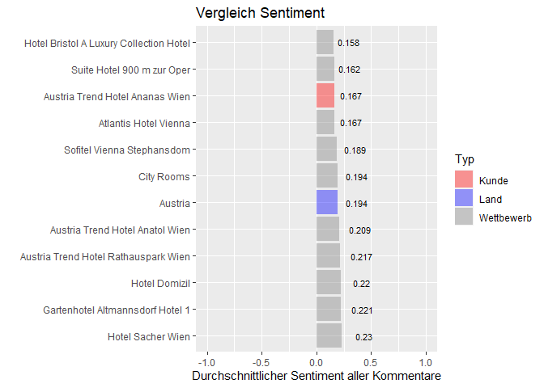

# 3) Gäste-Score

Im der folgenden Grafik sehen sie auf einer Skala von 0 (schlecht) bis 10 (gut) die durchschnittliche vergebene Punktzahl Ihrer Gäste. Zudem ist auch Ihre Vergleichsgruppe abgebildet, damit Sie Ihr Resultat mit der Konkurrenz vergleichen können.

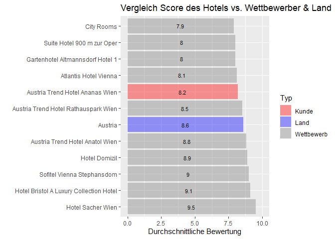

# 4) Text Mining

## 4.1) Topic Analyse des Hotels

Im Folgenden sehen Sie, welche Themen am meisten positiv und am meisten negativ genannt worden sind bei den Kommentaren Ihres Hotels. Dies ermöglicht es Ihnen, gezielt die positiven Punkte zu erhalten und die negativen zu Verbessern.

In den unterstehenden Grafiken sehen Sie die positiven wie auch negativen Themen der Kommentare.

### Negative Themen

In der folgenden Grafik sehen Sie die negativen Themen in den Kommentaren. Zudem sehen Sie auf der X-Achse, wie oft das Thema in den Kommentaren vorkommt und auf der Y-Achse wie negativ das Sentiment ist. Sie sollten sich dabei auf die Themen rechts unten fokussieren, da sie ein tiefes Sentiment haben und oft vorkommen. Dies liefert erste Anhaltspunkte, was aus Kundensicht an Ihrem Hotel optimiert werden könnte.

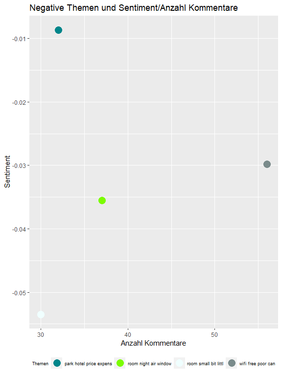

In der folgenden Grafik sehen Sie die negativen Themen und die Anzahl an Kommentaren, in denen sie vorkommen. Die Grafik zeigt, wie häufig über welche negativen Themen berichtet wird.

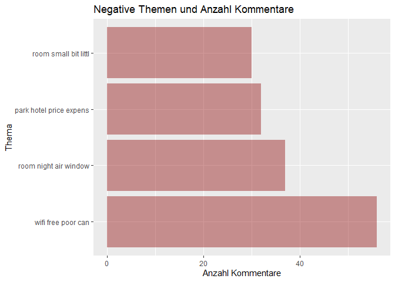

In der folgenden Grafik sehen Sie die negativen Themen und wie stark das negative Sentiment ist. Eine negativere Zahl (eine kleinere Zahl) des Sentimentes bedeutet, dass darüber negativer geschrieben wird. Daraus könnte abgeleitet werden, wie schlimm ein negatives Thema für die Kunden wirklich ist.

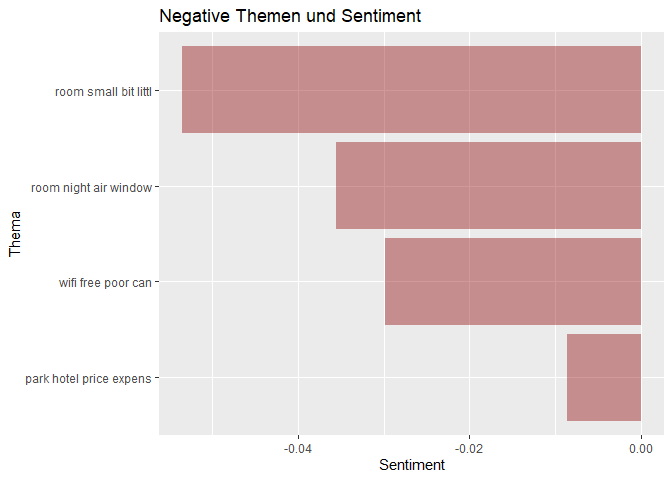

In der folgenden Grafik sehen Sie anhand einer Wortwolke, aus welchen Begriffen in den Kommentaren sich das häufigste negative Thema zusammensetzt. Diese Darstellung erweitert die Betrachtung der Themen, indem die mit dem Thema verbundenen Begriffe aufgezeigt werden. So können weitere Zusammenhänge der Themen mit Wörtern entdeckt werden.

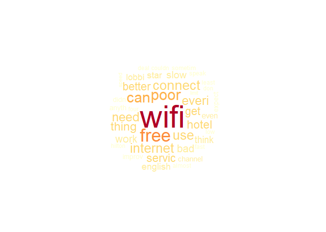

### Positive Themen

In der folgenden Grafik sehen Sie die positiven Themen in den Kommentaren. Zudem sehen Sie auf der X-Achse, wie oft das Thema in den Kommentaren vorkommt und auf der Y-Achse wie positiv das Sentiment ist. Sie sollten sich dabei auf die Themen rechts oben fokussieren, da sie ein gutes Sentiment haben und oft vorkommen. Diese können sehr gut kommuniziert werden. Zudem unterstützt diese Grafik in der Auswahl von Optimierungsmöglichkeiten. Dadurch, dass man erkennt, was den Kunden wichtig ist und positiv auffällt, kann man ableiten, was weiterhin so beibehalten oder allenfalls sogar noch etwas weiter optimiert werden soll.

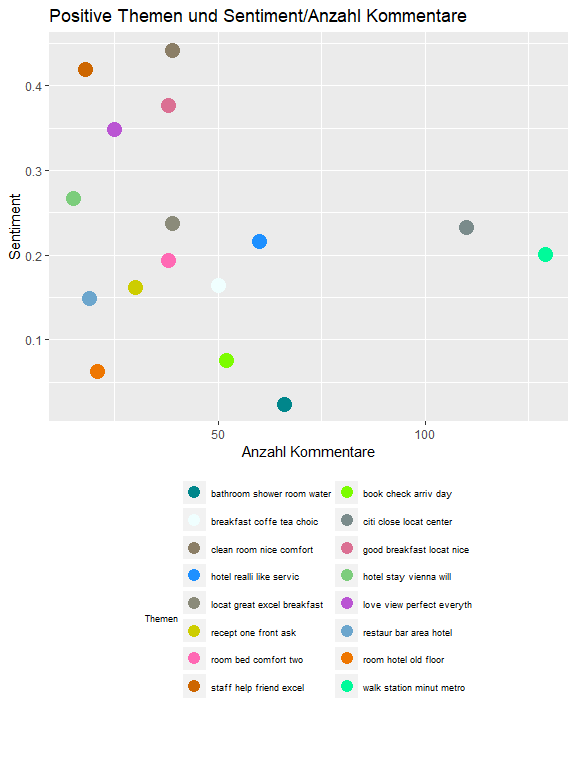

In der folgenden Grafik sehen Sie die positiven Themen und die Anzahl an Kommentaren, in denen sie vorkommen. Das soll helfen, herauszufinden, welche Themen von Personen häufig erwähnt werden.

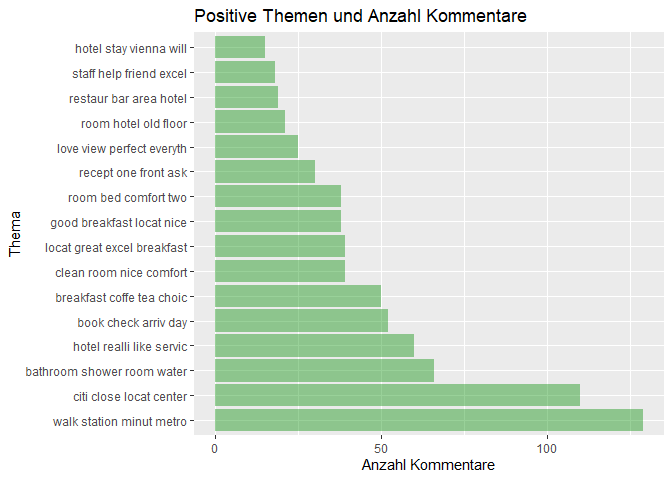

In der folgenden Grafik sehen Sie die positiven Themen und wie stark das positive Sentiment ist. Sie zeigt, wie positiv über die einzelnen Themen wirklich gesprochen wird.

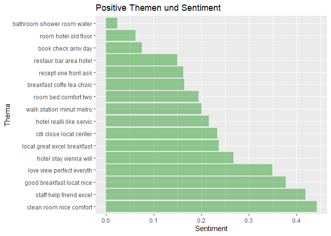

In der folgenden Grafik sehen Sie anhand einer Wortwolke, aus welchen Begriffen sich das häufigste positive Thema zusammensetzt. Diese Darstellung erweitert die Betrachtung der Themen, indem die mit den Themen verbundenen Begriffe aufgezeigt werden. So können weitere Zusammenhänge der Themen mit Wörtern entdeckt werden.

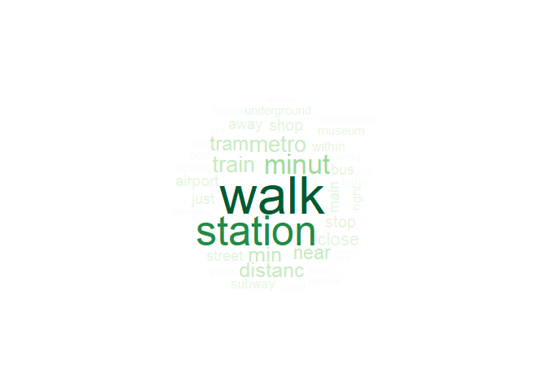

## 4.2) Topic Analyse der Vergleichsgruppe & des Landes

Im folgenden sehen Sie, welche Punkte am meisten positiv und am meisten negativ genannt worden sind innerhalb Ihrer Vergleichsgruppe. Dies ermöglicht es Ihnen, Ihre Ergebnisse mit der Konkurrenz zu vergleichen.

Die Interpretation und die Analyse ist dieselbe wie bei 4.1 und wird deshallb nicht nochmals in der gleichen Detaillierung ausgeführt.

### Vergleichsgruppe

Die Vergleichsgruppe konnten Sie selber wählen. Sie setzt sich in Ihrem Fall mit den bereits oben aufgelisteten Hotels zusammen.

#### Negative Themen

Auch in diesem Abschnitt werden wieder die negativen Themen und ihre Anzahl Kommentare und Sentiments angezeigt. In der unten stehenden Grafik handelt es sich aber um die Themen in den Kommentaren zu ihrer Vergleichsgruppe. Das hilft herauszufinden, auf welche Themen die Kunden bei ihren Vergleichshotels negativ reagieren. Mit grosser Wahrscheinlichkeit achten die Kunden auch bei Ihnen auf diese Themen. Es wäre deshalb vermutlich von Vorteil, diese ebenfalls zu optimieren.

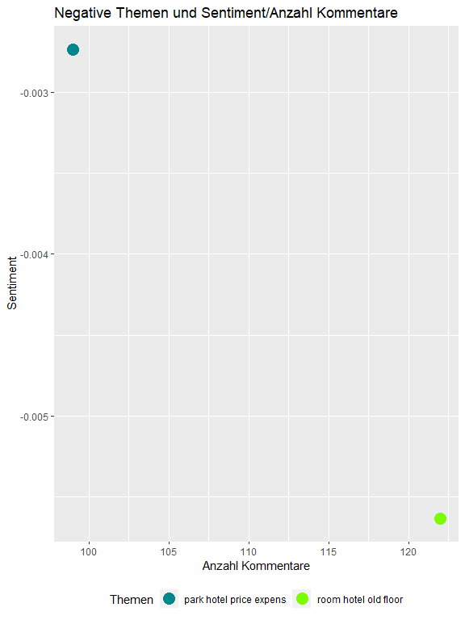

Auch hier wird etwas vertiefter aufgeschlüsselt, welches Thema wie viele Kommentare erhielt. Das hilft Ihnen dabei, die Themen entsprechend Ihren Bedürfnissen zu priorisieren.

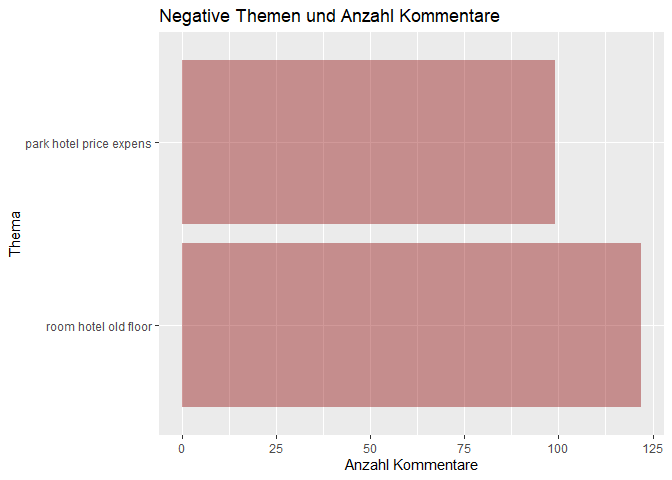

Dasselbe gilt für die Grafik mit den Sentiments der Themen Sie soll Ihnen helfen, die Themen einzuschätzen.

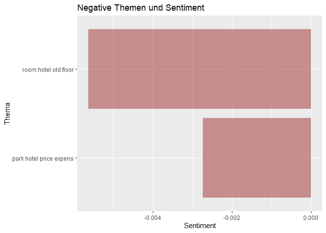

#### Positive Themen

Neben den negativen Themen der Vergleichsgruppe ist es ebenfalls interessant zu sehen, was von den Kunden in der Vergleichsgruppe positiv bemerkt wird. Das könnte durchaus auch für Ihr Hotel relevant sein. Auf diese Themen achten die Kunden wahrscheinlich auch bei Ihrem Hotel. Es empfiehlt sich also, auch das zu optimieren.

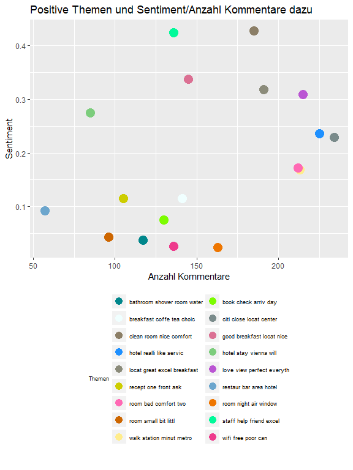

Um dann die unterschiedlichen Topics etwas besser priorisieren zu können, zeigen wir Ihnen hier die Anzahl Kommentare der einzelnen Themen im Vergleich.

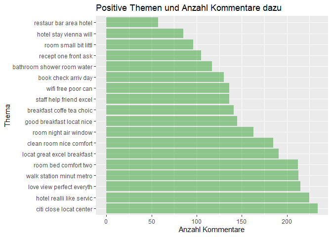

Dasselbe zeigen wir Ihnen mit dem Sentiment. So finden Sie schnell heraus, wie positiv die Kunden über die Themen sprechen.

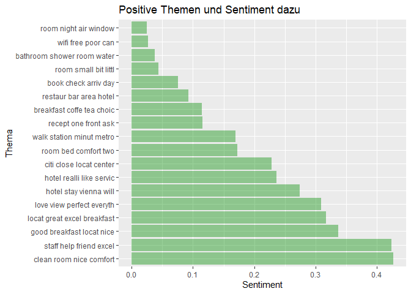

### Land

In diesem Teil des Berichts vergleichen wir Sie mit dem Land Austria.

Auf die Darstellung des Sentiments wird verzichtet, da sich dieses über den Landesdurchschnitt ausgleicht.

#### Negative Themen

Als negative Themen zeigen wir Ihnen die zehn negativsten Themen des Landes.

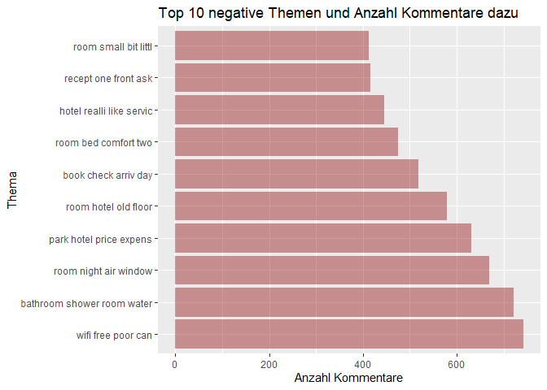

Diese Darstellung wird durch eine Wortwolke mit den negativen Themennamen ergänzt. Dies soll einen Überblick über die negativen Themen im Land verschaffen.

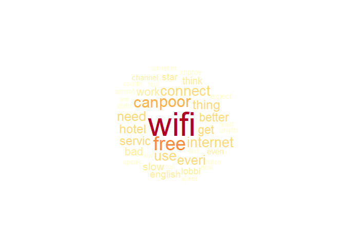

#### Positive Themen

Zum Vergleich mit den negativen Themen werden hier die zehn positivsten Themen dargestellt und die Anzahl Kommentare dazu.

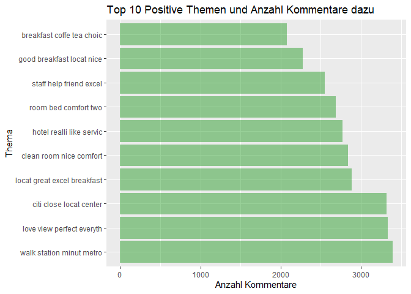

Auch hier werden die positiven Themennamen durch eine Wortwolke ergänzt.

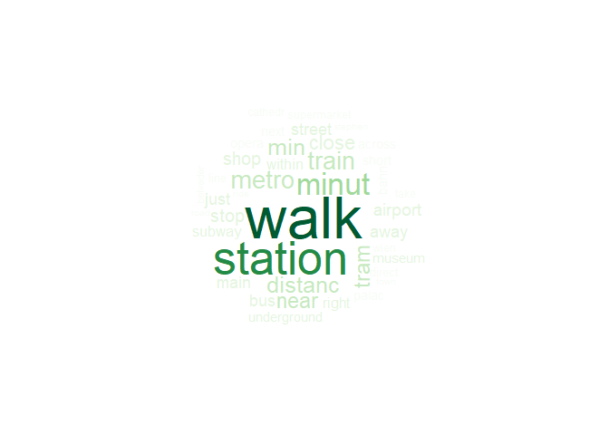

# 5) Gästenationalität

In der folgenden Auswertung finden Sie eine vertiefte Analyse basierend auf den Top 3 Touristen-Nationalitäten Ihres Landes. Damit können sie sicherstellen, dass Sie sich auf die wichtigsten Touristen ausrichten. Dadurch lässt sich das Problem reduzieren, dass der Kommentarstil je nach Nationalität unterschiedlich ist, was dazu führen kann, dass man auf die falsche Gruppe optimiert.

Anbei finden Sie wiederum die gleiche Analyse von vorhin, begrenzt und aufgeteilt nach den Top 3 Gästenationalitäten.

## Top Nationen

Die drei Top Nationen von Touristen im Land Austria sind:

- 1. : Germany
- 2. : Netherlands
- 3. : Switzerland

## Negative Themen

Pro Top Land werden in der nachfolgenden Grafik jeweils die Anzahl an negativen Kommentaren zu den einzelnen Themen dargestellt. Dies hilft herauszufinden, welche Besucher-Nationalitäten auf welche Themen besonders achten. Beispielsweise könnte damit pro Besuchergruppe geschaut werden, auf was sie besondern Wert legen. Dies könnte spezifisch für die Besuchergruppe optimiert werden.

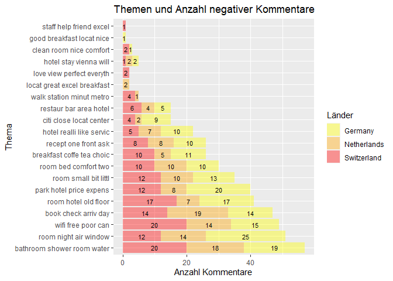

## Positive Themen

Die gleiche Darstellung zeigt sich nachfolgend für die Anzahl an positiven Kommentaren zu den einzelnen Themen.

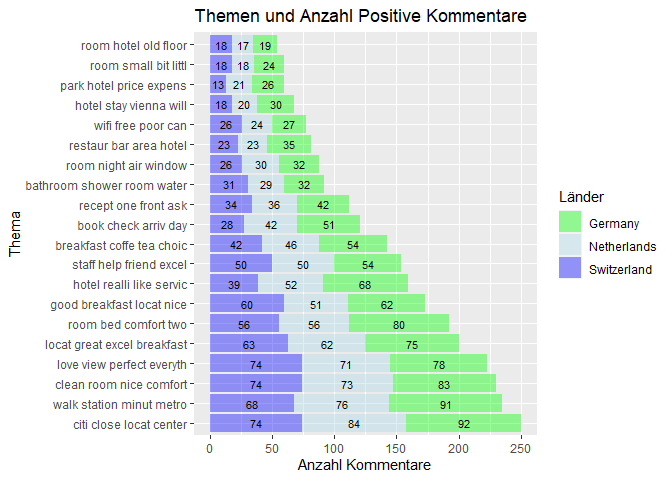

## Gesamtüberblick über die Themen

Für die Analysen-Nerds findet sich anbei noch ein vertiefter Einblick über das durchschnittliche Sentiment der Themen und deren Häufigkeit nach Nationalität. Also welches Thema wie häufig mit welchem Sentiment von den jeweiligen Top-Ländern erwähnt wurde.

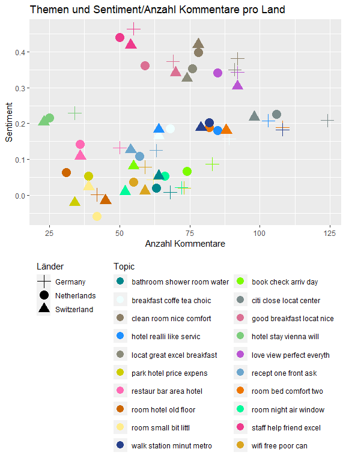